# Dados Ambientais

Fundamentos de Modelagem de Distribuição de Espécies no R - PPGBV 2021

Luíz Fernando Esser

7/06/2021

## Introdução

### Revisão da última aula

1. Baixar dados de presença de uma espécie;
2. Importar dados de presença usando a função `read.table`;
3. Data.frames;
4. Data Cleaning: Removendo NAs;
5. Data Cleaning: Removendo Coordenadas;
6. Data Cleaning: Removendo Duplicatas.  
   E lembre-se: Garbage in, garbage out.  
   E mais: dados de presença/ausência refletem uma condição ambiental e não geográfica.

## Baixar dados ambientais

Para que a nossa presença e a nossa ausência reflitam com qualidade uma determinada condição ambiental, nós precisamos selecionar variáveis ambientais adequadas. Para isso, vamos começar este roteiro fora do R baixando dados ambientais diretamente dos repositórios digitais através do nosso navegador. Para esta aula, vamos baixar dados do [WorldClim v.2.1](https://www.worldclim.org/data/worldclim21.html). Acesse o site e baixe as variáveis bioclimáticas na resolução 10 arc-minutos. Essa escala possibilitará que a gente trabalhe os rasters de forma mais rápida. Lembre-se, no entanto, que a resolução que escolhermos deve ser compatível com a área de distribuição da minha espécie. Eu usarei os dados da espécie *Ficus cestrifolia* (que baixamos no último encontro) para realizar as análises deste roteiro.

## Importando dados pro R

Vamos agora importar os dados ambientais e de espécie para o R:

```r
library(raster)
df <- read.csv("spp_data/Ficus.csv")
df <- df[,-1]
s <- stack(list.files("wc2.1_10m_bio", pattern=".tif", full.names = T))
```

Os dados de espécie são os mesmos que geramos na última aula e que já passaram por uma limpeza.

## Viéses estatísticos em variáveis ambientais

Antes de pensarmos na relação causal das nossas variáveis, primeiro precisamos pensar na nossa área de estudo e fazer uma varredura visual por alguns artefatos estatísticos. Esses artefatos são encontrados em variáveis trimestrais, devido a variação na janela temporal de medição da variável. Isso leva ao surgimento de linhas que não representam um gradiente contínuo. Observe, por exemplo a Amazônia e o Sahel quando plotamos a Bio 19:

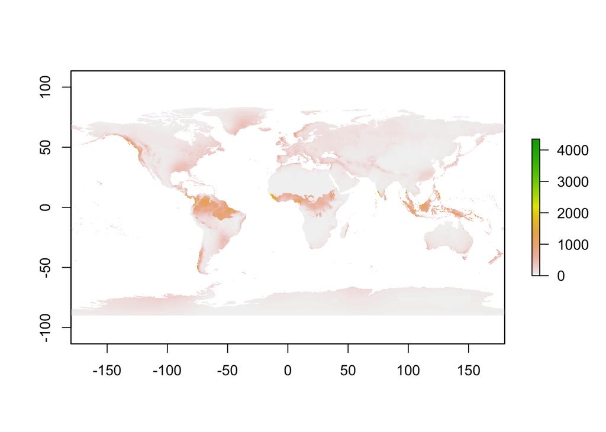

```r
plot(s$wc2.1_10m_bio_19)
```

Como apontado, essa conferência deve ser feita principalmente nas variáveis trimestrais (Bios 8 a 11 e 16 a 19). Para observar melhor a área de estudo, é possível usar a função `crop`. Caso alguma das variáveis possua tais artefatos, é necessário removê-las antes da próxima etapa. Imaginemos que precisamos excluir as Bios 10, 18 e 19. Faríamos isso da seguinte forma:

```r
names(s) # procurar pela posição das variáveis
```

```
##  [1] "wc2.1_10m_bio_1"  "wc2.1_10m_bio_10" "wc2.1_10m_bio_11" "wc2.1_10m_bio_12"
##  [5] "wc2.1_10m_bio_13" "wc2.1_10m_bio_14" "wc2.1_10m_bio_15" "wc2.1_10m_bio_16"
##  [9] "wc2.1_10m_bio_17" "wc2.1_10m_bio_18" "wc2.1_10m_bio_19" "wc2.1_10m_bio_2"
## [13] "wc2.1_10m_bio_3"  "wc2.1_10m_bio_4"  "wc2.1_10m_bio_5"  "wc2.1_10m_bio_6"
## [17] "wc2.1_10m_bio_7"  "wc2.1_10m_bio_8"  "wc2.1_10m_bio_9"
```

```r
s <- s[[-c(2, 10, 11)]] # eliminar posições 2, 10 e 11.
```

Eu posso conferir o número de camadas (layers) e os nomes das camadas do stack para ter certeza que exclui as variáveis corretas:

```r
names(s)
```

```
##  [1] "wc2.1_10m_bio_1"  "wc2.1_10m_bio_11" "wc2.1_10m_bio_12" "wc2.1_10m_bio_13"
##  [5] "wc2.1_10m_bio_14" "wc2.1_10m_bio_15" "wc2.1_10m_bio_16" "wc2.1_10m_bio_17"
##  [9] "wc2.1_10m_bio_2"  "wc2.1_10m_bio_3"  "wc2.1_10m_bio_4"  "wc2.1_10m_bio_5"
## [13] "wc2.1_10m_bio_6"  "wc2.1_10m_bio_7"  "wc2.1_10m_bio_8"  "wc2.1_10m_bio_9"
```

```r
s
```

```
## class      : RasterStack
## dimensions : 1080, 2160, 2332800, 16  (nrow, ncol, ncell, nlayers)
## resolution : 0.1666667, 0.1666667  (x, y)
## extent     : -180, 180, -90, 90  (xmin, xmax, ymin, ymax)
## crs        : +proj=longlat +datum=WGS84 +no_defs
## names      : wc2.1_10m_bio_1, wc2.1_10m_bio_11, wc2.1_10m_bio_12, wc2.1_10m_bio_13, wc2.1_10m_bio_14, wc2.1_10m_bio_15, wc2.1_10m_bio_16, wc2.1_10m_bio_17, wc2.1_10m_bio_2, wc2.1_10m_bio_3, wc2.1_10m_bio_4, wc2.1_10m_bio_5, wc2.1_10m_bio_6, wc2.1_10m_bio_7, wc2.1_10m_bio_8, ...
## min values :      -54.724354,       -66.311249,         0.000000,         0.000000,         0.000000,         0.000000,         0.000000,         0.000000,        1.000000,        9.131122,        0.000000,      -29.686001,      -72.500252,        1.000000,      -66.299416, ...
## max values :        30.98764,         29.15299,      11191.00000,       2381.00000,        484.00000,        229.00169,       5284.00000,       1507.00000,        21.14754,       100.00000,      2363.84595,        48.08275,        26.30000,        72.30175,        37.70479, ...
```

## Selecionar variáveis causais

Uma vez que nós conseguimos estudar nossa espécie e os motivos que levam ela a estar presente em determinados lugares, podemos começar a inferir quais variáveis podem ter relação de causa e efeito. Conhecer o habitat ocupado pela espécie também é uma forma de inferir causa e efeito nas variáveis bioclimáticas. Nesta etapa, nào existe um número ideal de variáveis ambientais a serem selecionadas. Como muitas são altamente correlacionadas, é provável que mais de uma seja selecionada com base no mesmo critério (por exemplo, as bios 6 e 11). Para saber a posição de cada raster em um stack, nós podemos usar a função `names`:

```r
names(s)
```

```
##  [1] "wc2.1_10m_bio_1"  "wc2.1_10m_bio_11" "wc2.1_10m_bio_12" "wc2.1_10m_bio_13"
##  [5] "wc2.1_10m_bio_14" "wc2.1_10m_bio_15" "wc2.1_10m_bio_16" "wc2.1_10m_bio_17"
##  [9] "wc2.1_10m_bio_2"  "wc2.1_10m_bio_3"  "wc2.1_10m_bio_4"  "wc2.1_10m_bio_5"
## [13] "wc2.1_10m_bio_6"  "wc2.1_10m_bio_7"  "wc2.1_10m_bio_8"  "wc2.1_10m_bio_9"
```

Vamos imaginar que as variáveis que nós selecionamos para Ficus cestrifolia sejam as bios 1, 2, 4, 8, 9, 12, 14, 15, 16, 17. Assim, usamos um sistema parecido com o anterior para ficar apenas com as variáveis desejadas.

```r
names(s) # procurar pela posição das variáveis
```

```
##  [1] "wc2.1_10m_bio_1"  "wc2.1_10m_bio_11" "wc2.1_10m_bio_12" "wc2.1_10m_bio_13"
##  [5] "wc2.1_10m_bio_14" "wc2.1_10m_bio_15" "wc2.1_10m_bio_16" "wc2.1_10m_bio_17"
##  [9] "wc2.1_10m_bio_2"  "wc2.1_10m_bio_3"  "wc2.1_10m_bio_4"  "wc2.1_10m_bio_5"
## [13] "wc2.1_10m_bio_6"  "wc2.1_10m_bio_7"  "wc2.1_10m_bio_8"  "wc2.1_10m_bio_9"
```

```r
s <- s[[c(1, 9, 11, 15, 16, 3, 5, 6, 7, 8)]] # ficar com posições 1, 9, 11, 15, 16, 3, 5, 6, 7, 8
names(s) # conferir camadas remanescentes
```

```
##  [1] "wc2.1_10m_bio_1"  "wc2.1_10m_bio_2"  "wc2.1_10m_bio_4"  "wc2.1_10m_bio_8"
##  [5] "wc2.1_10m_bio_9"  "wc2.1_10m_bio_12" "wc2.1_10m_bio_14" "wc2.1_10m_bio_15"
##  [9] "wc2.1_10m_bio_16" "wc2.1_10m_bio_17"
```

## Removendo Multicolinearidade

Um método bastante difundido de remover a multicolinearidade é utilizando o pacote `usdm`. Neste pacote, encontramos algumas funções que calculam o fator de inflação da variância (VIF). Dessa forma, automatizamos a exclusão das espécies de forma bastante eficiente. A função `vifcor` faz uma seleção de variáveis com base no VIF e na correlação entre as variáveis. Essa função primeiro calcula uma correlação de Pearson entre todos os pares de variáveis. Após, seleciona o par com maior correlação e exclui a variável com maior VIF dentro do par. Esses passos se repetem até que um limiar de correlação seje alcançado. Nesse exemplo vou usar um limiar de 0.5, isto é, nenhum par de variável terá correlação maior que 0.5. Note que a opção padrão é 0.9, então qualquer valor selecionado abaixo de 0.9 será considerado mais conservador que o habitual.  
Mas antes de rodarmos a função `vifcor`, precisamos preparar nossos dados ambientais. Precisamos fazer isso, pois queremos encontrar a multicolinearidade no contexto da nossa área de estudo e da área da nossa espécie, e não no contexto global. Assim, vamos criar um buffer ao redor das nossas presenças.

```r
library(rgeos)
```

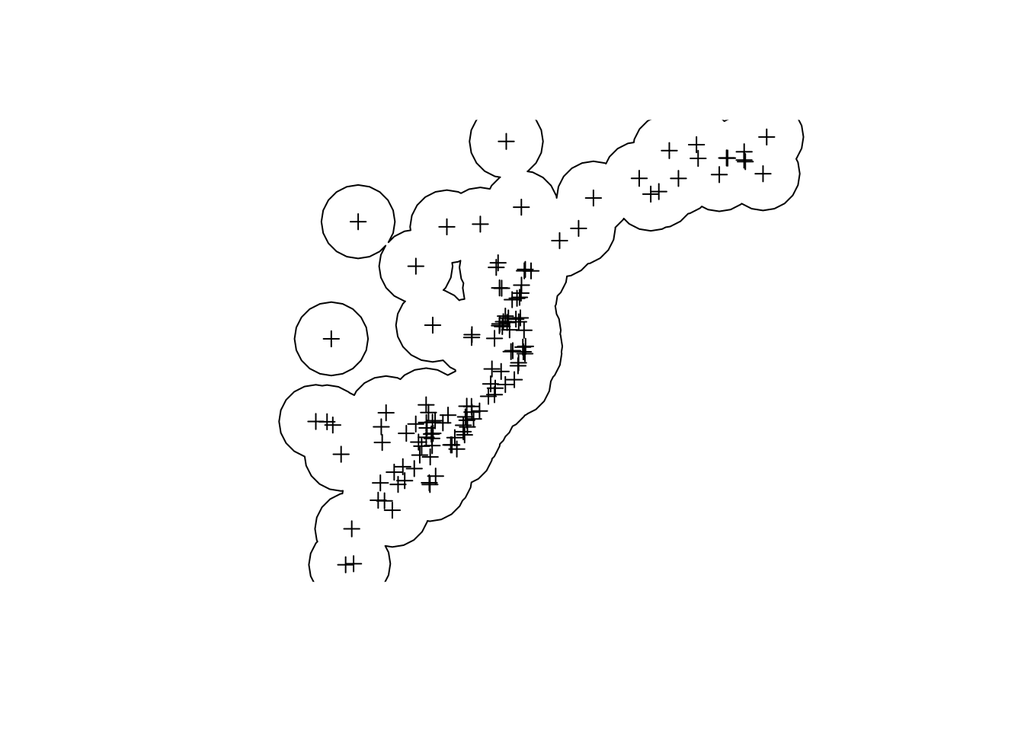

```r
df2 <- df
coordinates(df2) <- c(2,3)
buf <- gBuffer(df2, width=1)
plot(df2)
plot(buf, add=T)
```

Agora vamos restringir nossos dados ambientais para a área da nossa espécie. É importante, neste passo, criar um novo objeto para estocar o recorte que vamos fazer. Uma vez que o recorte é bem restrito, vamos usar ele somente para este passo.

```r
s2 <- stack(mask(crop(s,buf),buf))
```

Perceba que, ao invés de usar cada função em uma linha separada, eu juntei todas em uma única linha, otimizando tempo e espaço. O problema de fazer isso é que, caso surja um erro, é mais difícil de achar de onde ele veio. Agora podemos inserir nossos dados ambientais na função `vifcor`.

```r
library(usdm)
set.seed(1)
v <- vifcor(s2, th=0.5)
v
```

```
## 5 variables from the 10 input variables have collinearity problem:
##
## wc2.1_10m_bio_17 wc2.1_10m_bio_15 wc2.1_10m_bio_14 wc2.1_10m_bio_4 wc2.1_10m_bio_1
##
## After excluding the collinear variables, the linear correlation coefficients ranges between:
## min correlation ( wc2.1_10m_bio_12 ~ wc2.1_10m_bio_2 ):  -0.01465246
## max correlation ( wc2.1_10m_bio_16 ~ wc2.1_10m_bio_8 ):  0.4902217
##
## ---------- VIFs of the remained variables --------
##          Variables      VIF
## 1  wc2.1_10m_bio_2 1.114447
## 2  wc2.1_10m_bio_8 1.471642
## 3  wc2.1_10m_bio_9 1.129645
## 4 wc2.1_10m_bio_12 1.292770
## 5 wc2.1_10m_bio_16 1.718828
```

Veja que a função nos informa a quantidade de variáveis com problemas de multicolinearidade (5 de 10), nos informa a correlação máxima e mínima entre as variáveis selecionadas e informa quais variáveis foram selecionadas e qual o VIF de cada uma. Com base nesse resultado, podemos escolher se vamos ficar com todas as variáveis propostas, ou se vamos restringir ainda mais, ou restringir menos, ou alterar a área de recorte do passo anterior, e assim por diante. Uma função que ajuda, caso você queira ficar com todas variáveis selecionadas pela função vifcor, é a função `exclude` do próprio pacote `usdm`.

```r
s <- exclude(s, v)
s
```

```
## class      : RasterStack
## dimensions : 1080, 2160, 2332800, 5  (nrow, ncol, ncell, nlayers)
## resolution : 0.1666667, 0.1666667  (x, y)
## extent     : -180, 180, -90, 90  (xmin, xmax, ymin, ymax)
## crs        : +proj=longlat +datum=WGS84 +no_defs
## names      : wc2.1_10m_bio_2, wc2.1_10m_bio_8, wc2.1_10m_bio_9, wc2.1_10m_bio_12, wc2.1_10m_bio_16
## min values :         1.00000,       -66.29942,       -54.26688,          0.00000,          0.00000
## max values :        21.14754,        37.70479,        37.43358,      11191.00000,       5284.00000
```

## Juntando tudo

Com as nossas variáveis selecionadas, podemos delimitar agora nossa área de projeção. É aqui que vamos delimitar aonde o modelo vai extrair informações ambientais de presença e de ausência. Assim, podemos recortar nossas camadas ambientais usando shapes de estados, países, continentes, domínios biogeográficos, formações vegetacionais, fazendo buffers ao redor de presenças, utilizando o mínimo polígono convexo, excluindo regiões específicas com base em uma variável ambiental (como a altitude), e assim por diante. Aqui vou utilizar um buffer ao redor das presenças:

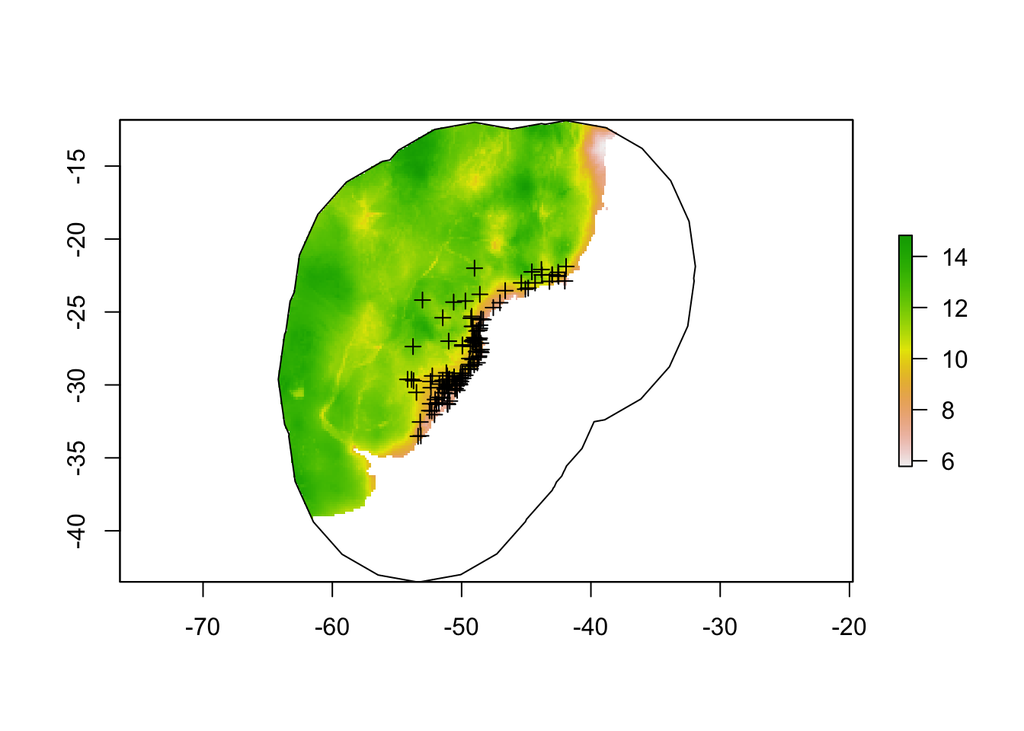

```r
buf <- gBuffer(df2, width=10)
s <- stack(mask(crop(s,buf),buf))
plot(s[[1]])
plot(buf, add=T)
plot(df2, add=T)
```

Com esses dados em mão, podemos colocar eles na função de pré-processamento `sdmData` do pacote `sdm`. Essa função, exige alguns argumentos. O primeiro é a função para calcular os modelos (argumento *formula*). Nele, indicamos uma igualdade usando o `~`, na esquerda indicamos a variável resposta (presença da espécie) e na direita as variáveis preditoras (variáveis ambientais). Ou seja:

```r
species ~ bio_1 + bio_2 + bio_3...
```

Transformando isso para os nossos dados, vamos ter que a variável resposta é o nome da primeira coluna de `df` (coluna `species`) que também é o nome da nossa variável dentro de `df2`. Os nomes de nossas variáveis respostas estão guardados dentro do objeto `s` e podemos obter eles através da função `names`. Nessa etapa eu acho muito vantajoso utilizar a função `reformulate`, assim:

```r
reformulate(termlabels = names(s), response = names(df2))
```

```
## species ~ wc2.1_10m_bio_2 + wc2.1_10m_bio_8 + wc2.1_10m_bio_9 +
##     wc2.1_10m_bio_12 + wc2.1_10m_bio_16
```

Perceba que a função retorna todos os nomes das variáveis de forma correta, o que pode ser bem útil quando temos muitas variáveis.  
O segundo (`train`) e terceiro (`predictors`) argumentos são os dados que vamos utilizar para treinar o modelo. Aqui indicamos os dados da espécie no formato shape, ou seja, o `df2` que é da classe `SpatialPointsDataFrame` e os dados ambientais no formato `RasterStack`. A própria função vai se encarregar de juntar as duas informações para nós. Por último, vamos pedir para a função criar dados de pseudoausências ou background pra nós (argumento `bg`). Fazemos isso fornecendo três informações: quantas pseudoausências queremos (`n`), qual o método que deve ser utilizado (`gRandom` escolhe aleatoriamente no espaço geográfico e `eRandom` escolhe aleatoriamente no espaço ambiental). Por último, indicamos se pseudoausências podem ou não cair junto de presenças com o argumento lógico `remove`. Se estamos trabalhando com MaxEnt e precisamos de dados de background, então utilizaremos `remove=FALSE`, mas se estamos focados em algoritmos que utilizam dados de ausências, então precisamos utilizar `remove=TRUE`. Juntando tudo, temos:

```r
library(sdm)
d <- sdmData(reformulate(termlabels = names(s), response = names(df2)),
                train = df2,
                predictors = s,
                bg=list(n=nrow(df),method='eRandom',remove=TRUE))
d
```

```
## class                                 : sdmdata
## ===========================================================
## number of species                     :  1
## species names                         :  Ficus.cestrifolia
## number of features                    :  5
## feature names                         :  wc2.1_10m_bio_2, wc2.1_10m_bio_8, wc2.1_10m_bio_9, ...
## type                                  :  Presence-Background
## has independet test data?             :  FALSE
## number of records                     :  249
## has Coordinates?                      :  TRUE
```

## Conclusão

Assim, chegamos ao final da nossa primeira etapa, o pré-processamento. Juntar dados ambientais e de presença da espécie é um dos pontos que temos que ter mais cuidado, uma vez que influenciam bastante no resultado final do nosso modelo. Além disso, é aqui que surgem as críticas mais difíceis de se contornar. A escolha das variáveis ambientais precisam sempre ser bem justificadas.

## Exercício

Agora é a sua vez de por a mão na massa. Caso ainda não tenha em mente as variáveis que possam ter causalidade com a presença da sua espécie, pule esta etapa selecionando as mesmas variáveis desse script. O importante aqui é treinarmos a parte de programação. Refletir sobre as variáveis preditoras é uma tarefa que pode levar bastante tempo e nós, como biólogos e formados nas áreas ambientais, já possuímos treinamento para isso. Então tente focar agora naquilo que não temos treinamento: a programação. Ao final, lembre-se de manter um registro escrito do que você fez, isso ajudará você na hora de escrever os métodos do artigo final.